# Oppgaver til leksjon 1 uten fasit

André Waage Rivenæs

1 10 2019

# Data import og vasking

1. Les inn Excel-filen “untidy_cashflow.xlsx” med hjelp av read_xlsx. Husk å spesifisere hvilke celler dere vil lese fra! Bruk: library(readxl). For hjelp skriv ?read_xlsx.

Husk å legge excel-filen i samme område hvor dere har opprettet RStudio-prosjektet. Dette tillater at du kan lese inn filen ved å skrive kun navnet på filen, istedenfor å måtte angi hele stien.

Merk at all kode skrives i de grå feltene under.

```r
df_cf <- read_xlsx(path = "Data/untidy_cashflow.xlsx", range = "E8:J11")
```

2. Gjør dataen tidy ved hjelp av pivot_wider og/eller pivot_longer. Husk reglene:
- hver variabel er en kolonne
- hver observasjon er en rad
- i en tabell er det kun en type “observasjonsenhet”

PS: Det er her (minst) to mulige løsninger. Den ene er best for plotting, mens den andre er mer tidy og egnet for modellering o.l.

```r
# Solution 1 #
tidy_df <- df_cf %>%
  pivot_longer(-År, values_to = "value", names_to = "type")

# Solution 2 #
tidy_df2 <- tidy_df %>%
  pivot_wider(names_from = type,
             values_from = value)
```

# Datatransformasjon

## Filtrering og seleksjon

1. Fjern sykkelturer som endte i “workshop” eller “UIP”. Disse er ikke vanlige stasjoner. Bruk funksjonen “filter” fra dplyr.
2. Fjern sykkelturer med varighet lenger enn 3600 sekunder.
3. Lag en ny dataframe kalt dates_only hvor du kun velger kolonnene started_at og ended_at.

```r
df <- df %>%
  filter(!(end_station_name %in% c("workshop","UIP"))) %>%
  filter(duration <= 3600)

dates_only <- df %>%
  select(started_at, ended_at)
```

## Mutate

Legg til følgende variabler i df ved å bruke mutate:

- Varighet i minutter (du har sekunder)
- Måned turen startet (bruk lubridate::month)
- Ukedag turen startet (bruk lubridate::day)
- Tidspunkt på dagen da turen startet (bruk lubridate::hour)
- En indikator på om turen ble gjennomført i helgen (lørdag/søndag), som er enten TRUE eller FALSE

```r
df <- df %>%
  mutate(duration_min = duration %/% 60,
         started_at_month = month(started_at),
         started_at_day = day(started_at),
         started_at_hour = hour(started_at),
         wday = wday(started_at, 1,7),
         is_weekend = wday %in% c("lør\\.","søn\\."))
```

## Gruppering og summarise

1. Grupper etter ukedag. Hvilken ukedag har flest sykkelturer? Bruk group_by + summarise og tellefunksjonen n().
2. Grupper etter endestasjon. Hvilken endestasjon har de lengste turene i snitt? Sorter resultatet etter gjennomsnittlig durasjon ved å bruke arrange.

```r
df_weekday <- df %>%
        group_by(wday) %>%
        summarise(n = n())

df_end_station <- df %>%
  group_by(end_station_name) %>%
  arrange()
```

# Visualisering

```r
df_mdp <- df %>%
  filter(start_station_name == "Møllendalsplass")
```

## Scatter plots

Bruk det mindre datasettet df_mdp (generert i kodesnutten over) for oppgavene under.

### a) Visualiser sammenhengen mellom durasjon og lengde på tur med et scatter plot

Hint: Bruk geom_point

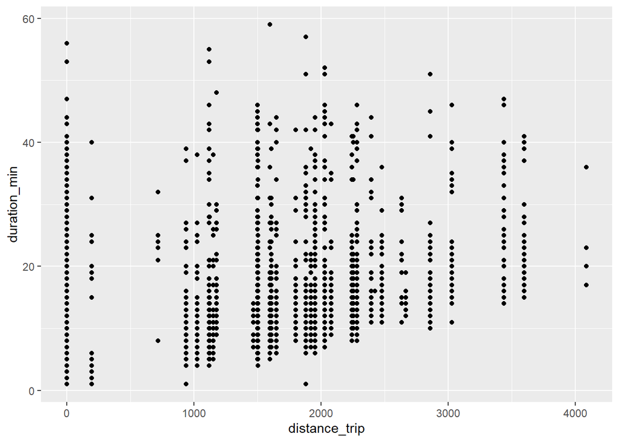

```r
p <- ggplot(data = df_mdp, aes(x = distance_trip, y = duration_min))
p +
  geom_point()
```

### b) Samme som i a), men bruk geom_jitter i stedet for geom_point

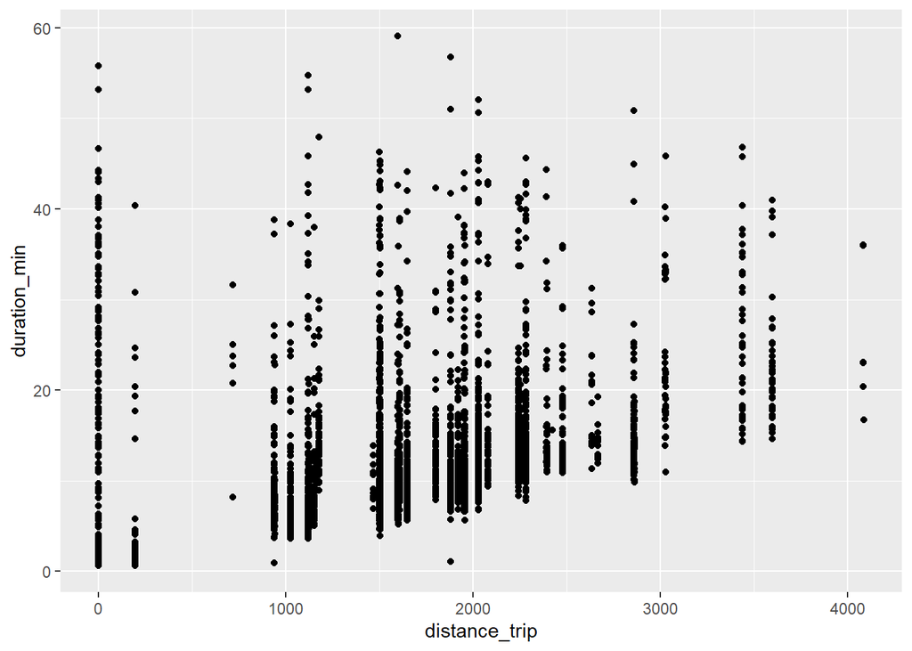

```r
p +
  geom_jitter()
```

### c) Legg til farge og transparens

Hint: geom-funksjonene tar inn argumenter. alpha = [et tall mellom 0 og 1] og color = “[navn på en farge]” styrer transparens og farge på punkter.

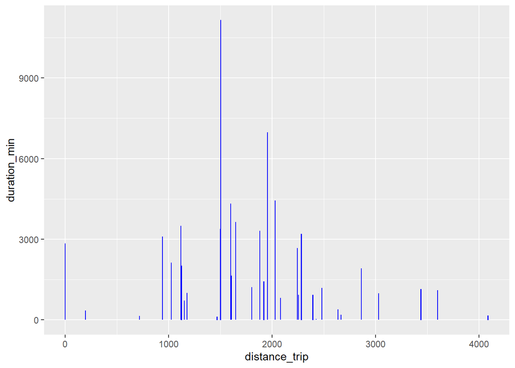

```r
p +
  geom_col(alpha = 0.5, color = "Blue")
```

### d) Samme som i b), men vis bare turer som varte i 30 minutter eller mindre

Bruk ylim(). Argumentet til ylim er en vektor med laveste grense som første element og øvre grense som andre element.En vektor lages med funksjonen c().

### e) Legg til farger til punktene for å visualisere hvilket tidspunkt på døgnet turen ble gjennomført

Hint: color er også et argument til aes()-funksjonen. Sett color = tidspunkt_tur_startet, og ggplot vil på magisk vis mappe farge til tidspunkt. Ser du noe interessant?

### f) Legg til en trendlinje til plottet i c)

Bruk geom_smooth

## Histogrammer

Bruk hele datasettet (df) for denne delen.

### a) Bruk et histogram for å visualisere distribusjonen til tidspunktet på dagen hvor turer starter

Bruk geom_histogram

### b) Som i a), men la hver bin representere en time

Skriv “?geom_histogram” i konsollen for å lære hvordan du kan styre antall bins. Hint: Syklene er bare tilgjengelig mellom 05:00 - 24:00.

### c) Legg til en farge til plottet i b)

Prøv “cornflowerblue”, “coral2” eller “forestgreen”. Forsøk å erstatte color-argumentet med fill.

## Density plots

### a) Lag et density plot som visualiserer distribusjonen til turenes varighet